# Diversification Rate Estimates Across Methods

```r
# you'll need all the packages
library(BAMMtools)
library(ape)
library(treeio) # install from bioconductor if missing
library(ggtree) # install from bioconductor if missing
library(reshape2)
library(tidytree)
library(dplyr)
library(readr)
library(coda)
library(tibble)
library(ggplot2)
library(cowplot)

# source functions for this tutorial
source("Scripts/compDivFunctions.R")
```

# Introduction

This tutorial will run you through helper functions for comparing the outputs of BAMM, PESTO, LSBDS, MTBD and ClaDS2. This file is an RMarkdown document. You can follow along in RStudio and run the “chunks” of code at once or line by line. Alternatively, you can check out the compiled version of this document as an HTML file and view the code and figures. Open the HTML document in an internet browser like Chrome or Firefox.

This tutorial will walk through processing and viewing the results of some of the most commonly-used diversification rate inference methods. The pipeline below visualizes the relationships between the functions and the designed workflow:

[figure not shown]

The output of these analysis will vary slightly depending on the platform you ran them on (eg., we ran BEAST on CIPRES and have CIPRES output files) and the output name. We’ve provided output files for one phylogeny from our analysis—A2017: Costaceae (André et. al 2016)—in the “Input” folder. Here, you’ll create a few output directories to store the results of processing these files.

```r
dir.create("Output/")
dir.create("Output/plots")
dir.create("Output/combined_posteriors")

phylo_path <- "Input/costaceae_A2017.tre"
phylo <- read.tree(phylo_path)
```

# 1. Combine chains, calculate net-diversification and take burnin.

The first step is to read in the MCMC chains, calculate net-diversification (see paper), remove burn-in and combine into a single MCMC trace The following code chunks will do using various helper functions.

## ClaDS2

We ran ClaDS2 using Julia but processed and saved the output as an .RData object using the save_ClaDS_in_R() function. The code below reads in that .RData object, removes burnin, and saves the data in a .csv file.

```r
claDS2_combined <- claDS2_combine_burin("input/ClaDS2/", burnin =.25)

write.csv(as.matrix(claDS2_combined),
          file = paste0(paste0("Output/combined_posteriors/clads2_combinedPosterior.csv")))
```

## LSBDS

RevBayes will produce a variety of output depending on the Rev script. The MCMC samples of lambda and mu values are located in a .log file that are typically the output of mnStochasticBranchRate() function. The following script will read in a directory with those logs to process.

```r
LSBDS_combined <- LSBDSMTBD_combine_burin(mcmc_chain_directory = "Input/LSBDS/",
                                          burnin=.05,
                                          MTBDorLSBDS = "LSBDS")
write.csv(LSBDS_combined,
          file = "Output/combined_posteriors/LSBDS_combinedPosterior.csv",
          row.names = F)
```

## MTBD

BEAST writes out MCMC samples from the posterior of lambda and mu in an annotated Nexus files; each MCMC samples contains the entire phylogeny. This is slightly inconvenient for our purpose because the phylogeny is fixed. The following code reads has two steps

1. The first uses MTBD_extract() to read in each tree from a BEAST trace, one at a time and extract rate estimates. The workhorse of the MTBD_extract() function is a modified read.beast() function from treeio named .parseTreeString(). It was written with the help Mike May. This writes a (2*(n+m)) by (y+1) matrix: where n and m are the number of tips and nodes in the phylogeny respectively, multiplied by two for both lambda and mu estimates. The number of MCMC samples with the first row corresponds to the node orders. This output will be similar to the LSBDS output.
2. Combine chains using the LSBDSMTBD_combine_burnin() function as above.

Step 1. might take a little bit of time depending on the size of the phylogeny. It should print a progress report every 10% of trees for a given MCMC trace.

```r
# I've encountered an error that reuqires you to increase the sys.setenv size. This is part of read_lines.

Sys.setenv(VROOM_CONNECTION_SIZE = 100000000)

# create directory for extracted posteriors
dir.create("Input/MTBD/posteriorsExtracted")


# Step 1. Run MTBD_extract() in a loop over individual BEAST MCMC chains
files <- list.files("Input/MTBD")
file_beast_trees <- grep(x=files,
                         pattern = ".*\\.trees$",
                         value = T)
count = 0
for(Beast_tree in file_beast_trees){
  count = count + 1

  posteriorOutput <- paste0("Input/MTBD/posteriorsExtracted/",Beast_tree,"_rates_chain", count,".csv")

  if( file.exists(posteriorOutput) == F ){
  MTBD <- MTBD_extract(paste0("Input/MTBD/",Beast_tree))
  write.csv(x=MTBD, file = paste0(posteriorOutput))

  } else(
    print(paste0(posteriorOutput, " has already been generated"))
  )
}
```

```
## [1] "Input/MTBD/posteriorsExtracted/A2017_default.rates_1.trees_rates_chain1.csv has already been generated"
## [1] "Input/MTBD/posteriorsExtracted/A2017_default.rates_2.trees_rates_chain2.csv has already been generated"
## [1] "Input/MTBD/posteriorsExtracted/A2017_default.rates_3.trees_rates_chain3.csv has already been generated"
```

```r
# Step 2.
MTBD_combine_burnin <- LSBDSMTBD_combine_burin(mcmc_chain_directory= "Input/MTBD/posteriorsExtracted",
                                              burnin =.25,
                                              MTBDorLSBDS = "MTBD")
write.csv(as.matrix(MTBD_combine_burnin),
              file = "Output/combined_posteriors/MTBD_combinedPosterior.csv",
              row.names = F)
```

## BAMM

The R package BAMMTools is a series of functions that help in processing the BAMM output. We will use their getEventData() and getMarginalBranchRateMatrix() functions to extract the lambda and mu estimates.

BAMM_combine() will take burnin and calculate net-div.

```r
BAMM_directory <- "Input/BAMM"
dir.create(paste0(BAMM_directory,"/posteriorsExtracted"))

eventData_output_file_path <- list.files(BAMM_directory,full.names = T) %>%
  grep(x = ., pattern = "event_data",value = T)

edata <- getEventData(phylo,
                      eventData_output_file_path,
                      burnin=.1)
```

```
## Reading event datafile:  Input/BAMM/event_data_A2017.tr.pr
##      ...........
## Read a total of 2000 samples from posterior
##
## Discarded as burnin: GENERATIONS <  199000
## Analyzing  1801  samples from posterior
##
## Setting recursive sequence on tree...
##
## Done with recursive sequence
```

```r
marg <- getMarginalBranchRateMatrix(edata)
write.csv(marg, paste0(BAMM_directory,"/posteriorsExtracted/BAMMrates.csv"))


BAMM_combine_burnin <- BAMM_combine(paste0(BAMM_directory,"/posteriorsExtracted/"))

write.csv(BAMM_combine_burnin,
          "Output/combined_posteriors/BAMM_combinedPosterior.csv",
          row.names = F)
```

# 2 - Calculate Summary Statistics and Organize nodes

Summary Statistics 1. MAP 2. Posterior Median 3. Posterior Mean 4. Quantile Intervals - using the quantile() 5. HPD Intervals

```r
LSBDS_combinedPosterior <- LSBDS_summarizePosterior(LSBDS_posterior_path=paste0("Output/combined_posteriors/LSBDS_combinedPosterior.csv"), Phylogeny_path = phylo_path)
bamm_combinedPosterior <- BAMM_summarizePosterior(bamm_posterior_path=paste0("Output/combined_posteriors/BAMM_combinedPosterior.csv"), Phylogeny_path = phylo_path)
MTBD_combinedPosterior <- MTBD_summarizePosterior(MTBD_posterior_path=paste0("Output/combined_posteriors/MTBD_combinedPosterior.csv"), Phylogeny_path = phylo_path)
clads2_combinedPosterior<- clads2_summarizePosterior(clads2_posterior_path=paste0("Output/combined_posteriors/clads2_combinedPosterior.csv"), Phylogeny_path = phylo_path)

pesto_path <- list.files("Input/PESTO",full.names = T) %>%
    grep(x = ., pattern = ".tsv", value = T)
Pesto_summarized <- Pesto_summarizePosterior(pesto_path = pesto_path,
                                             Phylogeny_path = phylo_path)

# Merge all summaries into a single data frame
combinedPosteriors <- merge(LSBDS_combinedPosterior,bamm_combinedPosterior, by = "Index") %>%
  merge(MTBD_combinedPosterior, by = "Index") %>%
  merge(clads2_combinedPosterior, by = "Index") %>%
  merge(Pesto_summarized, by = "Index")

# Specify if branches are nodes or tips
combinedPosteriors$TipOrNode <- ifelse(combinedPosteriors$Index <= length(phylo$tip.label), "Tip", "Node")

write.csv(combinedPosteriors,
          paste0("Output/combined_posteriors/combinedPosterior.csv"),
          row.names=F)
```

# 3. Plot Phylogeny

## a. comp_branch_plots

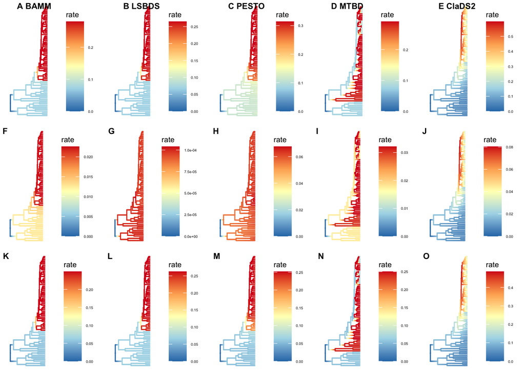

```r
combined <- read.csv(paste0("Output/combined_posteriors/combinedPosterior.csv"),
                     header = TRUE)

AllMethods <- comp_branch_plots(summaryStatisticsData = combined,
                          parameter = "median",
                          Branch_index = combined$Index,
                          phylo_path = phylo_path,
                          print_scale = F)

AllMethods_scaled <- comp_branch_plots(summaryStatisticsData = combined,
                          parameter = "median",
                          Branch_index = combined$Index,
                          phylo_path = phylo_path,
                          print_scale = T)
AllMethods
```

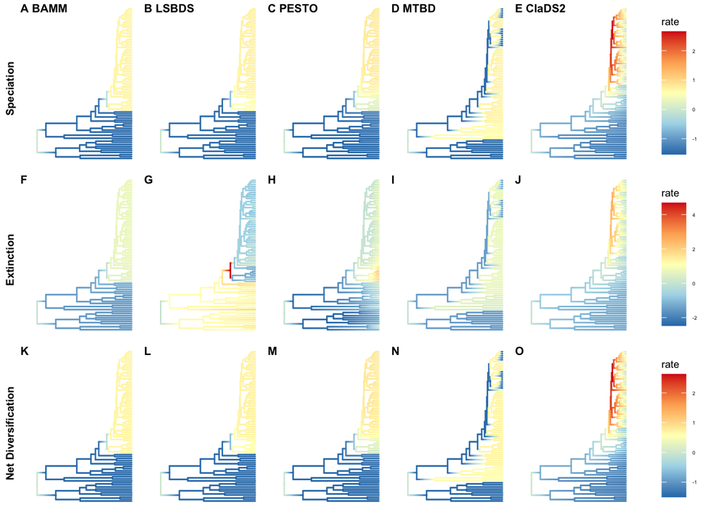

```r
AllMethods_scaled
```

```r
# save to file
pdf(paste0("Output/plots/paintedTrees_allmethods.pdf"))
print(AllMethods)
print(AllMethods_scaled)
dev.off()
```

Users can subset there merged file to only plot some methods. For example here we subset our data to only plots LSBDS, PESTO and MTBD

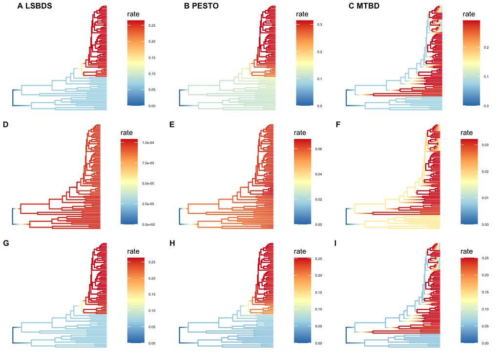

```r
combined <- read.csv(paste0("Output/combined_posteriors/combinedPosterior.csv"),
                     header = TRUE)

# Subset by combined by all the
combined_MTBD <- combined[,grep(x = colnames(combined),pattern = "MTBD")]
combined_LSBDS <- combined[,grep(x = colnames(combined),pattern = "LSBDS")]
combined_PESTO <- combined[,grep(x = colnames(combined),pattern = "PESTO")]

# Merge them all
combined_LSBDSPESTOMTBD <- cbind(combined_LSBDS,combined_PESTO,combined_MTBD)

LSBDSPESTOMTBD_paintedTrees <- comp_branch_plots(summaryStatisticsData = combined_LSBDSPESTOMTBD,
                          parameter = "median",
                          Branch_index = combined$Index,
                          phylo_path = phylo_path,
                          print_scale = F)

LSBDSPESTOMTBD_paintedTrees_scaled <- comp_branch_plots(summaryStatisticsData = combined_LSBDSPESTOMTBD,
                          parameter = "median",
                          Branch_index = combined$Index,
                          phylo_path = phylo_path,
                          print_scale = T)

LSBDSPESTOMTBD_paintedTrees
```

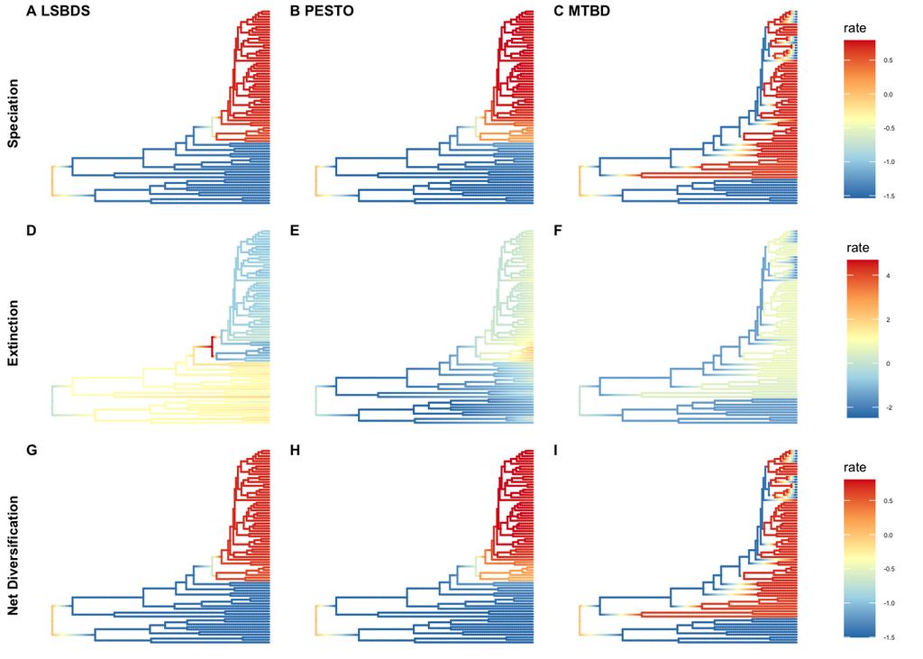

```r
LSBDSPESTOMTBD_paintedTrees_scaled
```

```r
# save to file
pdf(paste0("Output/plots/paintedTrees_LSBDSPESTOMTBD.pdf"))
print(LSBDSPESTOMTBD_paintedTrees)
print(LSBDSPESTOMTBD_paintedTrees_scaled)
dev.off()
```

## plot_rate_phylo() and plot_rate_phylo_scaled()

If user want more freedom they can take advantage of plot_rate_phylo() and plot_rate_phylo_scaled(). These are the two plotting functions underlying comp_branch_plots(). plot_rate_phylo() simply takes in a object class “tidytree” with relevant information as such,

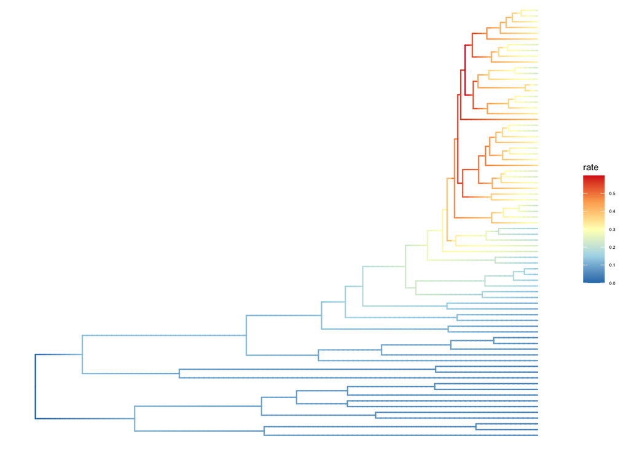

```r
# Read in data
combined <- read.csv(paste0("Output/combined_posteriors/combinedPosterior.csv"),
                     header = TRUE)

phylo_tib <- read.tree(phylo_path) %>%
    as.tibble(phylo)

# Data Wrangle
combined_Plot <- data.frame(combined$ClaDS2_median_lambda,
                            combined$Index)
names(combined_Plot) <- c("value","node")
phylo_tib_data <- dplyr::full_join(phylo_tib, combined_Plot, by = 'node') %>%
  treeio::as.treedata()

# Plot and Export
p <- plot_rate_phylo(phylo_tib_data);p
```

```r
# save to file
pdf(paste0("Output/plots/ClaDS2_rate_plot.pdf"))
print(p)
dev.off()
```

Using plot_rate_phylo_scaled() only makes sense if you are plotting two methods together, as scale function is applied to the dataset. plot_rate_phylo_scaled() requires an additional set of arguments “gradient_max” and “gradient_min” to determine how to scale the phylogeny

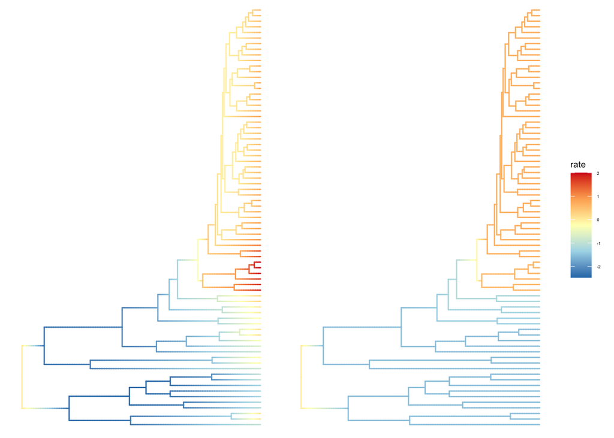

```r
# Read in data
combined <- read.csv(paste0("Output/combined_posteriors/combinedPosterior.csv"),
                     header = TRUE)

phylo_tib <- read.tree(phylo_path) %>%
    as.tibble(phylo)

# Scale BAMM and PESTO extinction
combined_scale <- data.frame(combined$PESTO_mu,combined$BAMM_median_mu) %>%
  scale() %>%
  as.data.frame()

# Identify min and Max values
combined_scale_melt <- reshape2::melt(combined_scale)
scale_max <- max(combined_scale)
scale_min <- min(combined_scale)

# Plot PESTO
combined_scale_PESTO <- data.frame(combined_scale$combined.PESTO_mu,
                                   combined$Index)
names(combined_scale_PESTO) <- c("value","node")
phylo_tib_data <- dplyr::full_join(phylo_tib, combined_scale_PESTO, by = 'node')%>%
  treeio::as.treedata()
PESTOscaled <- plot_rate_phylo_scaled(phylo_tib_data,
                                  gradient_max = scale_max,
                                  gradient_min = scale_min)

# Plot BAMM
combined_scale_BAMM <- data.frame(combined_scale$combined.BAMM_median_mu,
                                   combined$Index)
names(combined_scale_BAMM) <- c("value","node")
phylo_tib_data <- dplyr::full_join(phylo_tib, combined_scale_BAMM, by = 'node')%>%
  treeio::as.treedata()
BAMMscaled <- plot_rate_phylo_scaled(phylo_tib_data,
                                  gradient_max = scale_max,
                                  gradient_min = scale_min)

# Combine into a single plot with cowplot package
legend_scaled <- cowplot::get_legend( PESTOscaled )
scaled_plot <- cowplot::plot_grid(PESTOscaled + theme(legend.position="none"),
                                  BAMMscaled + theme(legend.position="none"),
                                  legend_scaled,
                                  rel_widths = c(1,1,.2),
                                  nrow = 1)
scaled_plot
```

```r
# save to file
pdf(paste0("Output/plots/scaled_rate_plot.pdf"))
scaled_plot
dev.off()
```